# Estudio variabilidad estructural proteica

30/01/2016

## Conjuntos de proteinas

### Conjunto teorico

260 mutantes de 1mct (223 sitios) simuladas con el modelo mutacional MND con ANM *R0* = 12 y *Fmax* = 2 (solo para LFENM). Para determinar que sitios mutar, se alineo 1mct con cada una de las proteinas del conjunto, se obtuvieron los indices de los sitios alineados pero mutados y se simularon 10 mutantes por cada par de proteinas, obteniendose un total de 260 mutantes. Luego, para el analisis, se tomaron como alineados los sitios alineados de 1mct para cada par de proteinas.

### Conjunto experimental

26 proteinas de la familia de serinProteases. Las proteinas tienen un promedio de identidad secuencial de 46%. El core del alineamiento de la familia es de 181 sitios.

La caracterizacion del conjunto experimental se muestra a continuacion:

```
##    pdbid nsites naligned identity       MSD
## 1   1bbr    259      223 39.01345 1.1401668
## 2   1ppb    259      223 39.91031 1.0669141
## 3  1hcga    236      217 38.70968 1.2760847
## 4  1kigh    241      222 40.54054 1.4545170
## 5  1fxya    228      223 58.29596 5.2448285
## 6   2ptn    223      223 81.16592 0.1902498
## 7  1trma    223      223 80.71749 0.1219509
## 8  1a0ja    223      223 72.64574 0.3499862
## 9   2tbs    222      222 65.76577 0.1907805
## 10  1ab9    227      216 46.75926 1.0472141
## 11  1ton    227      222 40.99099 1.2365863
## 12  2pka    232      223 42.15247 0.8861316
## 13 1npma    223      218 44.95413 0.8297446
## 14 1azza    226      216 38.88889 1.3564538
## 15  3est    240      220 40.00000 0.9167658
## 16 1a0la    244      216 41.20370 1.6909949
## 17 1lmwb    248      218 35.77982 1.6831887
## 18 1a5ia    265      216 39.35185 3.0609942
## 19 1a5ha    252      216 41.66667 1.7187211
## 20 1fuja    221      205 41.95122 1.3111545
## 21 1hnee    218      205 37.07317 1.4990609
## 22  1a7s    221      207 31.40097 1.3542140
## 23 3rp2a    224      207 35.74879 1.1025826
## 24  1klt    226      209 39.71292 1.3134431
## 25 1dfpa    228      215 39.53488 1.6129725
## 26  1sgt    223      205 34.14634 1.5518592
```

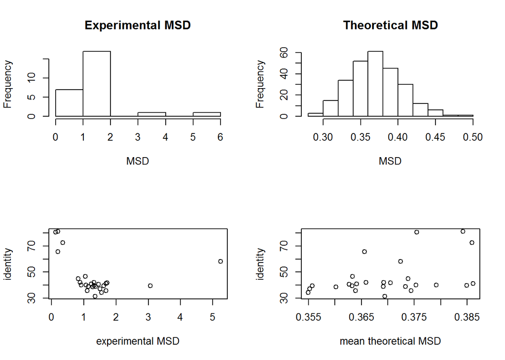

## Comparaciones

### RHO y AUC

Las distribuciones de *auc* y *rho* para cada conjunto se muestran a continuacion (azul= teorico, rojo = experimental)

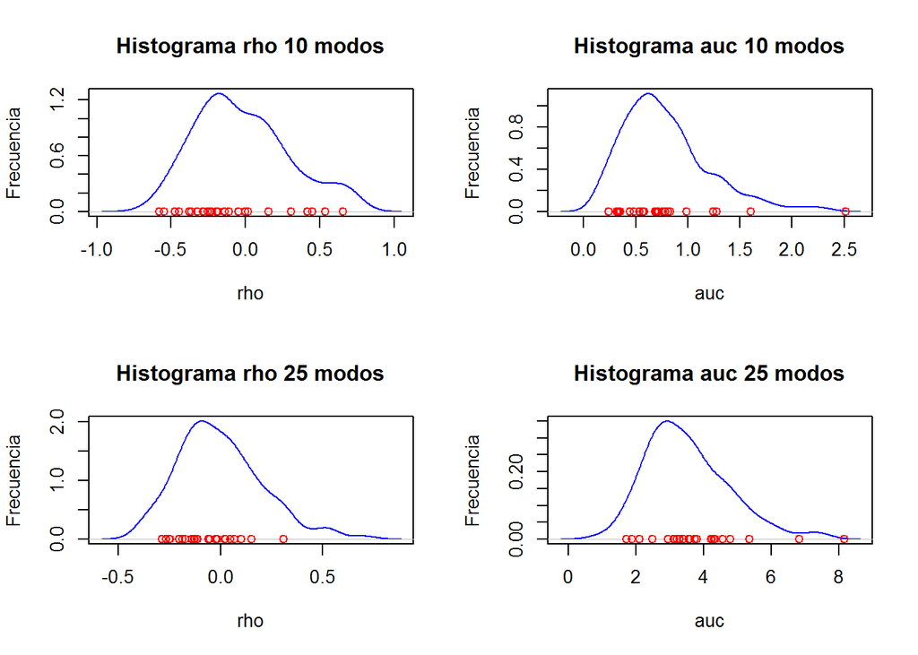

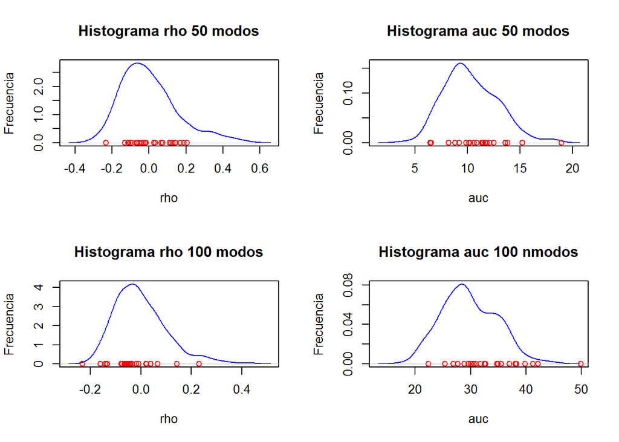

## Pn y Qn

Las distribuciones de *Pn* y *Qn* de los conjuntos son las siguientes:

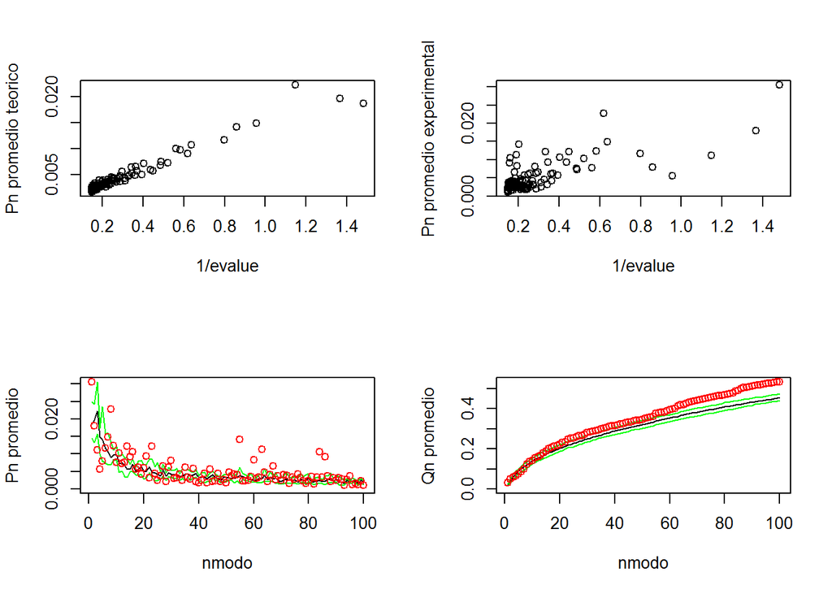

Negro: Teorico Rojo: Experimental Verdes: Cuartiles 0.05 y 0.95 de 10 grupos de 26 mutantes teoricas.